# Predicting distributional ranges of rocky intertidal species using a multi-dataset approach

### Wave fetch (Burrows)

2009 wave fetch data is downloaded from https://www.sams.ac.uk/people/researchers/burrows-professor-michael/.

```r
# Import
fetch <- rast("Data/Environmental_data/wave_fetch.asc")

# Adjust 'fact' depending on raster size (larger = faster, less detail)
fetch_small <- aggregate(fetch, fact = 5, fun = mean)
```

```
|---------|---------|---------|---------|
=========================================
```

```r
#Set land cells (value = 1) and open ocean (value = 0) to NA
fetch_small[fetch_small == 1] <- NA
fetch_small[fetch_small == 0] <- NA

# Convert downsampled raster to data frame
fetch_df <- as.data.frame(fetch_small, xy = TRUE) %>% na.omit()

# Check column names
colnames(fetch_df)  # usually "x", "y", "layer"
```

```
[1] "x"          "y"          "wave_fetch"
```

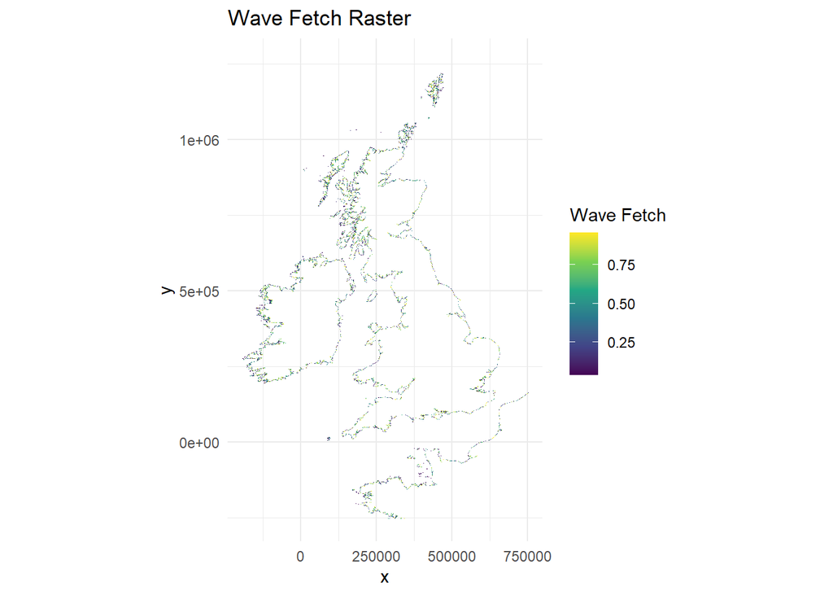

```r
# Plot with ggplot
fetch_plot <- ggplot(fetch_df, aes(x = x, y = y, fill = wave_fetch)) +
  geom_raster() +
  scale_fill_viridis_c() +
  coord_equal() +
  theme_minimal() +
  labs(fill = "Wave Fetch",
       title = "Wave Fetch Raster")

fetch_plot
```

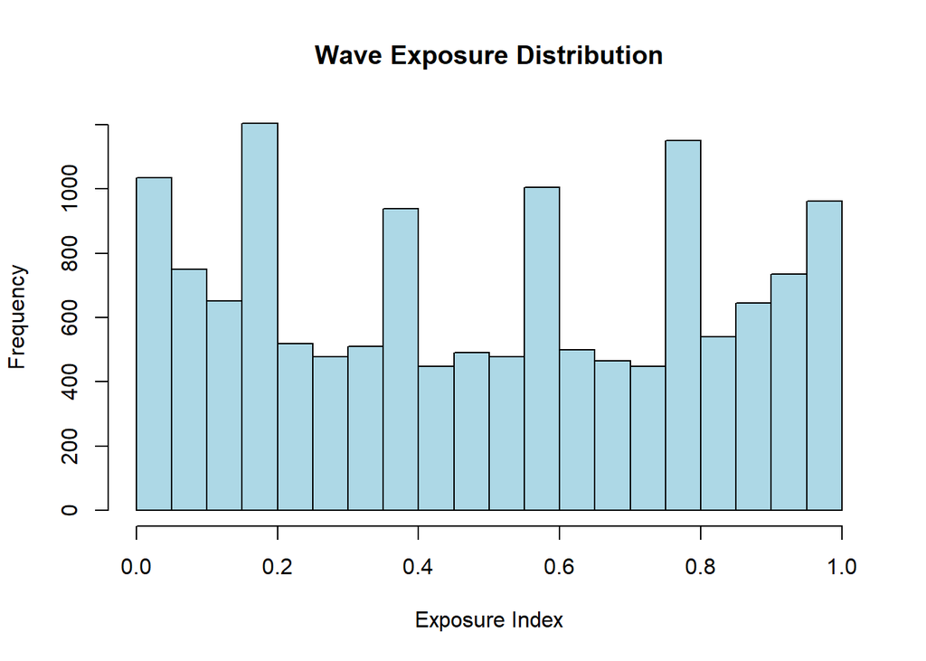

```r
# Assuming 'fetch' is your SpatRaster object
hist(fetch_small, main = "Wave Exposure Distribution", xlab = "Exposure Index", col = "lightblue")
```

```r
# make same as environmental data
# Convert combined raster back to sf polygons if you want an sf version
fetch_sf <- as.polygons(fetch_small, dissolve = FALSE)  # dissolve=FALSE keeps each cell separate
fetch_sf <- st_as_sf(fetch_sf)

#Check polygon CRS; if missing, assign the original projected CRS
st_crs(fetch_sf) <- 27700  # Example: British National Grid, adjust if different

# Widen buffer by 1000 m (example)
wf_buffered <- st_buffer(fetch_sf, dist = 1000)

#Reproject polygons to match raster CRS
fetch_sf_proj <- st_transform(wf_buffered, crs(ocean_temp_present))

# Rasterize
fetch_raster <- rasterize(vect(fetch_sf_proj), ocean_temp_present, field = "wave_fetch", background = NA)
```

Provided an updated data set in 2012 accessible here - https://figshare.com/articles/dataset/Wave_fetch_GIS_layers_for_the_UK_and_Ireland_at_200m_scale/12029682?file=22107477.

Values represent the log base 10 of the summed distance to the nearest land (as the number of 200m grid cell units) across all 32 11.5° sectors. This is the data we’ll use for our models. Higher values mean more exposed, lower values mean less exposed.

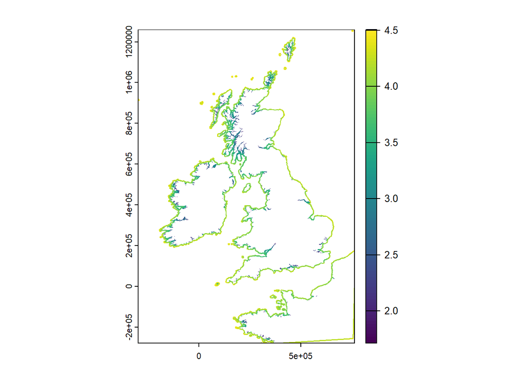

```r
# load and plot
fetch_2012 <- rast("Data/Environmental_data/log10_eu200m1a.tif")
plot(fetch_2012)
```

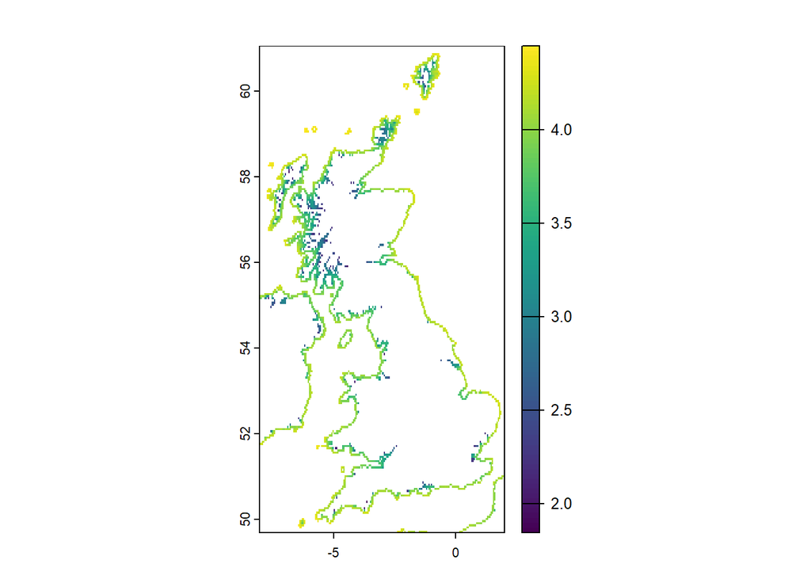

```r
# Reproject fetch to WGS84 (same CRS as ocean_temp)
fetch_wgs84 <- project(fetch_2012, ocean_temp_present)

# Resample to match ocean_temp grid (interpolates to same cells)
fetch_resampled <- resample(fetch_wgs84, ocean_temp_present, method = "bilinear")
plot(fetch_resampled)
```

### Create stacks

```r
# stack
enviro_vars_current <- stack(c(
  ocean_temp_avg,
  #air_temp_present,
  ph_avg,
  #terrain,
  #rock_rast_combined,
  fetch_resampled
))

names(enviro_vars_current) <- c(
  "ocean_temp",
  #"air_temp_2000",
  #"air_temp_2020",
  "ph",
  #"coastline_binary",
  #"rocky_substrate",
  "wave_fetch"
  )

names(enviro_vars_current)
```

```
[1] "ocean_temp" "ph"         "wave_fetch"
```

```r
#plot
png(
  "Figures/enviro_vars_current.png",
  width = 2000,
  height = 2000,
  res = 300
)

plot(enviro_vars_current,
     main = c("Sea Surface Temperature (SST)", "pH", "Wave fetch"))

dev.off()
```

```r
# future


enviro_vars_future <- stack(c(
  ocean_temp_projected_90,
  #air_temp_projected,
  ph_projected_90,
  #terrain,
  #rock_rast_combined,
  fetch_resampled
))

names(enviro_vars_future) <- c(
  "ocean_temp",
  #"air_temp_2000",
  #"air_temp_2020",
  "ph",
  #"coastline_binary",
  #"rocky_substrate",
  "wave_fetch" # we need the future
)


#plot
png(
  "Figures/enviro_vars_future.png",
  width = 2000,
  height = 2000,
  res = 300
)

plot(enviro_vars_future,
     main = c("Sea Surface Temperature (SST)", "pH", "Wave fetch"))

dev.off()
```

```r
# Combine both stacks into one for plot
enviro_both <- stack(enviro_vars_current, enviro_vars_future)
enviro_both <- dropLayer(enviro_both, nlayers(enviro_both))

# add in rocky layer
rock_rast_raster <- raster(rock_rast_combined)
names(rock_rast_raster) <- "rocky_substrate_binary"
enviro_both <- stack(enviro_both, rock_rast_raster)

#plot

# Save high-resolution plot
png(
  "Figures/enviro_vars.png",
  width = 2500,
  height = 2000,
  res = 300
)

plot(enviro_both,
     main = c("Sea surface temperature (Current)",
              "pH (Current)",
              "Wave fetch",
              "Sea surface temperature (Future)",
              "pH (Future)",
              "Rocky substrate")
)

dev.off()
```

### Check co-linearity

```r
#pairs(sdmdata[,2:5], cex=0.1) #air temp and ocean temp highly correlate
#pairs(sdmdata[,5:8], cex=0.1) #pH with temp looks fine
```

## Creating SDM data sets

### Visualize occurrence over variables

Semibalanus

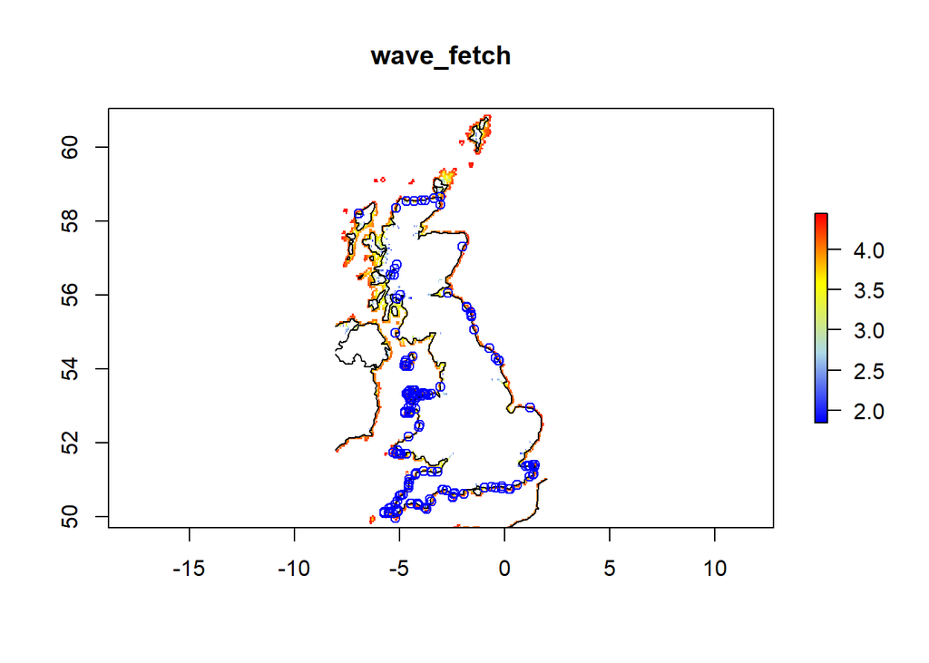

```r
# second layer of the SpatRaster (current ocean temp)
# we do not need the first column (species name)
final_visual_semibalanus  <- final_visual_semibalanus[,-1]

# plot
plot(enviro_vars_current, 3, col = cols)
lines(wrld)
points(final_visual_semibalanus$lon, final_visual_semibalanus$lat, col = 'blue')
```

Chthamalus

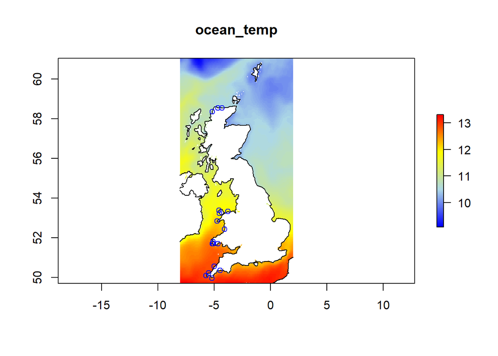

```r
# remove row
chthamalus_montagui_obs_both_methods <- chthamalus_montagui_obs_both_methods[,-1]

#plot
plot(enviro_vars_current, 1, col = cols)
lines(wrld)
points(chthamalus_montagui_obs_both_methods,
       col='blue')
```

### Fixed unmatched occurrence points to environmental data

We use the `extract` function from the `raster` package to check where they overlap.

```r
# remove source column
final_visual_semibalanus_reduced <- final_visual_semibalanus[,-3]

#extract
presvals_semibalanus_visual <- extract(enviro_vars_current, final_visual_semibalanus_reduced)

head(presvals_semibalanus_visual) # all NA!
```

```
     ocean_temp ph wave_fetch
[1,]         NA NA         NA
[2,]         NA NA         NA
[3,]         NA NA         NA
[4,]         NA NA         NA
[5,]         NA NA         NA
[6,]         NA NA         NA
```

We can see that some points are being treated as land rather than sea (we’ve got quite a few NAs). We need to find the closest point which is classed as coastline and use that instead.

Let’s do Semibalanus first.

```r
# snap the valid environmental cells from function created earlier
semibalanus_corrected_marclim <- snap_to_nearest_valid(
  enviro_vars_current,
  semibalanus_marclim_broad)

# check
envir_terra <- rast(enviro_vars_current)
presvals_semibalanus_corrected_marclim <- extract(envir_terra, semibalanus_corrected_marclim) # this looks better

# remove the ID variable
presvals_semibalanus_corrected_marclim <- presvals_semibalanus_corrected_marclim[,-1]

# check the new data
head(semibalanus_corrected_marclim)
```

```
      lon     lat
1 -4.5592 50.8362
2 -2.3760 50.6330
3 -2.4600 50.5130
4 -2.4544 50.5414
5 -1.9450 50.6070
6 -2.4448 50.6062
```

```r
# for the PA version
marclim_broad_sp_PA_semibalanus <- marclim_broad_sp_PA %>% select(-c("Chthamalus.montagui"))

semibalanus_corrected_marclim_PA <- snap_to_nearest_valid(
  enviro_vars_current,
  marclim_broad_sp_PA_semibalanus)

# snap the valid environmental cells from function created earlier
presvals_semibalanus_corrected_marclim_PA <- extract(envir_terra, semibalanus_corrected_marclim_PA) # this looks better

# remove the ID variable
presvals_semibalanus_corrected_marclim_PA <- presvals_semibalanus_corrected_marclim_PA[,-1]

# check the new data
head(semibalanus_corrected_marclim_PA)
```

```
      lon     lat
1 -4.5592 50.8362
2 -2.3760 50.6330
3 -2.4600 50.5130
4 -2.4544 50.5414
5 -1.9450 50.6070
6 -2.1250 50.5750
```

```r
#add PA back in
semibalanus_corrected_marclim_PA$Semibalanus.balanoides = marclim_broad_sp_PA_semibalanus$Semibalanus.balanoides
```

```r
# snap the valid environmental cells from function created earlier
semibalanus_corrected_gbif <- snap_to_nearest_valid(
  enviro_vars_current,
  semibalanus_GBIF_clean_reduced)

# check
presvals_semibalanus_corrected_gbif <- extract(envir_terra, semibalanus_corrected_gbif[, c("lon", "lat")]) # this looks better

# remove the ID variable
presvals_semibalanus_corrected_gbif <- presvals_semibalanus_corrected_gbif[,-1]

# check the new data
head(semibalanus_corrected_gbif)
```

```
        lon      lat
1 -3.075000 53.47500
2 -3.075000 53.47500
3 -3.473825 51.21275
4 -3.455478 51.21076
5 -4.725000 54.07500
6 -4.512921 53.41149
```

```r
# Count how many presence points have all variables NA (or any NA)
na_points <- apply(presvals_semibalanus_corrected_gbif, 1, function(x) any(is.na(x)))

table(na_points) #no NAs
```

```
na_points
FALSE
   37
```

```r
# snap the valid environmental cells from function created earlier
semibalanus_corrected_combined <- snap_to_nearest_valid(
  enviro_vars_current,
  semibalanus_GBIF_eDNA)

# check
presvals_semibalanus_corrected_combined <- extract(envir_terra, semibalanus_corrected_combined[, c("lon", "lat")]) # this looks better

# remove the ID variable
presvals_semibalanus_corrected_combined <- presvals_semibalanus_corrected_combined[,-1]

# check the new data
head(semibalanus_corrected_combined)
```

```
        lon      lat
1 -3.075000 53.47500
2 -3.075000 53.47500
3 -3.473825 51.21275
4 -3.455478 51.21076
5 -4.725000 54.07500
6 -4.512921 53.41149
```

```r
# Count how many presence points have all variables NA (or any NA)
na_points <- apply(presvals_semibalanus_corrected_combined, 1, function(x) any(is.na(x)))

table(na_points) #no NAs
```

```
na_points
FALSE
   57
```

Now let’s do Chthamalus.

```r
# snap the valid environmental cells from function created earlier
chthamalus_corrected_marclim <- snap_to_nearest_valid(
  enviro_vars_current,
  chthamalus_marclim_broad)

# check
envir_terra <- rast(enviro_vars_current)
presvals_chthamalus_corrected_marclim <- extract(envir_terra, chthamalus_corrected_marclim) # this looks better

# remove the ID variable
presvals_chthamalus_corrected_marclim <- presvals_chthamalus_corrected_marclim[,-1]

# check the new data
head(chthamalus_corrected_marclim)
```

```
      lon     lat
1 -4.5592 50.8362
2 -2.3760 50.6330
3 -2.4600 50.5130
4 -2.4544 50.5414
5 -1.9450 50.6070
6 -2.1250 50.5750
```

```r
# for the PA version

# call function we created eariler to correct points
marclim_broad_sp_PA_chthamalus <- marclim_broad_sp_PA %>% select(-c("Semibalanus.balanoides"))

# snap the valid environmental cells from function created earlier
chthamalus_corrected_marclim_PA <- snap_to_nearest_valid(
  enviro_vars_current,
  marclim_broad_sp_PA_chthamalus)

presvals_chthamalus_corrected_marclim_PA <- extract(envir_terra, chthamalus_corrected_marclim_PA) # this looks better

# remove the ID variable
presvals_chthamalus_corrected_marclim_PA <- presvals_chthamalus_corrected_marclim_PA[,-1]

# check the new data
head(chthamalus_corrected_marclim_PA)
```

```
      lon     lat
1 -4.5592 50.8362
2 -2.3760 50.6330
3 -2.4600 50.5130
4 -2.4544 50.5414
5 -1.9450 50.6070
6 -2.1250 50.5750
```

```r
#add PA back in
chthamalus_corrected_marclim_PA$Chthamalus.montagui = marclim_broad_sp_PA_chthamalus$Chthamalus.montagui
```

```r
# snap the valid environmental cells from function created earlier
chthamalus_corrected_gbif <- snap_to_nearest_valid(
  enviro_vars_current,
  chthamalus_GBIF_clean_reduced)

# check
presvals_chthamalus_corrected_gbif <- extract(envir_terra, chthamalus_corrected_gbif[, c("lon", "lat")]) # this looks better

# remove the ID variable
presvals_chthamalus_corrected_gbif <- presvals_chthamalus_corrected_gbif[,-1]

# check the new data
head(chthamalus_corrected_gbif)
```

```
        lon      lat
1 -5.061596 50.14580
2 -4.975000 50.57500
3 -5.056024 50.14791
4 -5.057851 50.14730
5 -5.062843 50.14545
6 -3.325000 51.22500
```

```r
# Count how many presence points have all variables NA (or any NA)
na_points <- apply(presvals_chthamalus_corrected_gbif, 1, function(x) any(is.na(x)))

table(na_points) #no Nas
```

```
na_points
FALSE
   25
```

```r
# snap the valid environmental cells from function created earlier
chthamalus_corrected_combined <- snap_to_nearest_valid(
  enviro_vars_current,
  chthamalus_GBIF_eDNA)

# check
presvals_chthamalus_corrected_combined <- extract(envir_terra, chthamalus_corrected_combined[, c("lon", "lat")]) # this looks better

# remove the ID variable
presvals_chthamalus_corrected_combined <- presvals_chthamalus_corrected_combined[,-1]

# check the new data
head(chthamalus_corrected_combined)
```

```
        lon      lat
1 -5.061596 50.14580
2 -4.975000 50.57500
3 -5.056024 50.14791
4 -5.057851 50.14730
5 -5.062843 50.14545
6 -3.325000 51.22500
```

```r
# Count how many presence points have all variables NA (or any NA)
na_points <- apply(presvals_chthamalus_corrected_combined, 1, function(x) any(is.na(x)))

table(na_points) #no NAs
```

```
na_points
FALSE
   36
```

## `biomod2` workflow

We are going to build our models and forecasts using the `biomod2` package. We will build four models, visualize their outputs and forecast changes into the far future (2100).

### Data formatting

The MarClim data will be used to evaluate all models (individual or ensemble) - this is defined when formatting the data in this section.

#### Data set 1 (Semibalanus - visual)

```r
# pa as df and tidy
# marclim
semibalanus_corrected_marclim_PA_df <- as.data.frame(semibalanus_corrected_marclim_PA)

# occurences
semibalanus_corrected_gbif_df <- as.data.frame(semibalanus_corrected_gbif)
semibalanus_corrected_gbif_df$Semibalanus.balanoides <- 1 #add p for gbif

# Extract env values
env_vals <- extract(envir_terra, semibalanus_corrected_gbif)

# Bind back to coordinates
pts_with_vals <- cbind(semibalanus_corrected_gbif_df, env_vals)

# Remove NAs
pts_clean <- pts_with_vals[complete.cases(pts_with_vals), c("lon", "lat")]
```

Now let’s put all our data elements into the `BIOMOD_FormatingData` function.

```r
set.seed(seed.val.set)

myBiomodData_semibalanus_visual <- BIOMOD_FormatingData(
  resp.var = rep(1, nrow(pts_clean)),
  # presence-only
  expl.var = enviro_vars_current,
  resp.xy = pts_clean,
  resp.name = 'Semibalanus.balanoides',
  PA.nb.rep = 1,
  # Number of pseudo-absence sets (10 recom by biomd)
  PA.nb.absences = 3 * nrow(pts_clean),
  # Number of pseudo-absences (~3 x number of presences)
  PA.strategy = 'random',
  eval.resp.var = semibalanus_corrected_marclim_PA_df$Semibalanus.balanoides,
  # Evaluation responses (0/1)
  eval.resp.xy = semibalanus_corrected_marclim_PA_df[, c("lon", "lat")],
  # Evaluation locations,
  eval.expl.var = presvals_semibalanus_corrected_marclim_PA,
  #filter.raster = TRUE #autofilter,
  na.rm = FALSE,
  seed.val = seed.val.set
)

summary(myBiomodData_semibalanus_visual)

# Save BIOMOD_FormatingData plot to PNG
png("Figures/myBiomodData_semibalanus_visual.png",
    width = 2000, height = 1500, res = 300)  # size in pixels, resolution in DPI
plot(myBiomodData_semibalanus_visual)
dev.off()
```

#### Data set 2 (Semibalanus - combined)

```r
# occurences
semibalanus_corrected_combined_df <- as.data.frame(semibalanus_corrected_combined)
semibalanus_corrected_combined_df$Semibalanus.balanoides <- 1 #add p for gbif

# Extract env values
env_vals <- extract(envir_terra, semibalanus_corrected_combined)

# Bind back to coordinates
pts_with_vals <- cbind(semibalanus_corrected_combined_df, env_vals)

# Remove NAs
pts_clean <- pts_with_vals[complete.cases(pts_with_vals), c("lon", "lat")]
```

Now let’s put all our data elements into the `BIOMOD_FormatingData` function.

```r
set.seed(seed.val.set)

myBiomodData_semibalanus_combined <- BIOMOD_FormatingData(
  resp.var = rep(1, nrow(pts_clean)) ,
  # presence-only
  expl.var = enviro_vars_current,
  resp.xy = pts_clean,
  resp.name = 'Semibalanus.balanoides',
  PA.nb.rep = 1,
  # Number of pseudo-absence sets (10 recom by biomd)
  PA.nb.absences = 3 * nrow(pts_clean),
  # Number of pseudo-absences (~3 x number of presences)
  PA.strategy = 'random',
  eval.resp.var = semibalanus_corrected_marclim_PA_df$Semibalanus.balanoides,
  # Evaluation responses (0/1)
  eval.resp.xy = semibalanus_corrected_marclim_PA_df[, c("lon", "lat")],
  # Evaluation locations,
  eval.expl.var = presvals_semibalanus_corrected_marclim_PA,
  #filter.raster = TRUE #autofilter
  na.rm = FALSE,
  seed.val = seed.val.set
)

summary(myBiomodData_semibalanus_combined)

# Save BIOMOD_FormatingData plot to PNG
png("Figures/myBiomodData_semibalanus_combined.png",
    width = 2000, height = 1500, res = 300)  # size in pixels, resolution in DPI
plot(myBiomodData_semibalanus_combined)
dev.off()
```

#### Data set 3 (Chthamalus - visual)

```r
# pa as df and tidy
# marclim
chthamalus_corrected_marclim_PA_df <- as.data.frame(chthamalus_corrected_marclim_PA)

# occurences
chthamalus_corrected_gbif_df <- as.data.frame(chthamalus_corrected_gbif)
chthamalus_corrected_gbif_df$Semibalanus.balanoides <- 1 #add p for gbif

# Extract env values
env_vals <- extract(envir_terra, chthamalus_corrected_gbif)

# Bind back to coordinates
pts_with_vals <- cbind(chthamalus_corrected_gbif_df, env_vals)

# Remove NAs
pts_clean <- pts_with_vals[complete.cases(pts_with_vals), c("lon", "lat")]
```

```r
set.seed(seed.val.set)

myBiomodData_chthamalus_visual <- BIOMOD_FormatingData(
  resp.var = rep(1, nrow(pts_clean)) ,
  # presence-only
  expl.var = enviro_vars_current,
  resp.xy = pts_clean,
  resp.name = 'Chthamalus.montagui',
  PA.nb.rep = 1,
  # Number of pseudo-absence sets (10 recom by biomd)
  PA.nb.absences = 3 * nrow(pts_clean),
  # Number of pseudo-absences (~3 x number of presences)
  PA.strategy = 'random',
  eval.resp.var = chthamalus_corrected_marclim_PA_df$Chthamalus.montagui,
  # Evaluation responses (0/1)
  eval.resp.xy = chthamalus_corrected_marclim_PA_df[, c("lon", "lat")],
  # Evaluation locations,
  eval.expl.var = presvals_chthamalus_corrected_marclim_PA,
  #filter.raster = TRUE #autofilter
  na.rm = FALSE,
  seed.val = seed.val.set
)

myBiomodData_chthamalus_visual

# Save BIOMOD_FormatingData plot to PNG
png("Figures/myBiomodData_chthamalus_visual.png",
    width = 2000, height = 1500, res = 300)  # size in pixels, resolution in DPI
plot(myBiomodData_chthamalus_visual)
dev.off()
```

#### Data set 4 (Chthamalus - combined)

```r
# occurences
chthamalus_corrected_combined_df <- as.data.frame(chthamalus_corrected_combined)
chthamalus_corrected_combined_df$Semibalanus.balanoides <- 1 #add p for gbif

# Extract env values
env_vals <- extract(envir_terra, chthamalus_corrected_combined)

# Bind back to coordinates
pts_with_vals <- cbind(chthamalus_corrected_combined_df, env_vals)

# Remove NAs
pts_clean <- pts_with_vals[complete.cases(pts_with_vals), c("lon", "lat")]
```

```r
set.seed(seed.val.set)

myBiomodData_chthamalus_combined <- BIOMOD_FormatingData(
  resp.var = rep(1, nrow(pts_clean)) ,
  # presence-only
  expl.var = enviro_vars_current,
  resp.xy = pts_clean,
  resp.name = 'Chthamalus.montagui',
  PA.nb.rep = 1,
  # Number of pseudo-absence sets (10 recom by biomd)
  PA.nb.absences = 3 * nrow(pts_clean),
  # Number of pseudo-absences (~3 x number of presences)
  PA.strategy = 'random',
  eval.resp.var = chthamalus_corrected_marclim_PA_df$Chthamalus.montagui,
  # Evaluation responses (0/1)
  eval.resp.xy = chthamalus_corrected_marclim_PA_df[, c("lon", "lat")],
  # Evaluation locations,
  eval.expl.var = presvals_chthamalus_corrected_marclim_PA,
  #filter.raster = TRUE #autofilter
  na.rm = FALSE,
  seed.val = seed.val.set
)

myBiomodData_chthamalus_combined

# Save BIOMOD_FormatingData plot to PNG
png("Figures/myBiomodData_chthamalus_combined.png",
    width = 2000, height = 1500, res = 300)  # size in pixels, resolution in DPI
plot(myBiomodData_chthamalus_combined)
dev.off()
```

We now have four `biomod` objects ready for modelling.

```r
summary(myBiomodData_semibalanus_visual)
```

```
      dataset run   PA Presences True_Absences Pseudo_Absences Undefined
1     initial  NA <NA>        37             0               0       111
2  evaluation  NA <NA>       218            18               0         0
3 calibration  NA  PA1        37             0             111        NA
```

```r
summary(myBiomodData_semibalanus_combined)
```

```
      dataset run   PA Presences True_Absences Pseudo_Absences Undefined
1     initial  NA <NA>        57             0               0       171
2  evaluation  NA <NA>       218            18               0         0
3 calibration  NA  PA1        57             0             171        NA
```

```r
summary(myBiomodData_chthamalus_visual)
```

```
      dataset run   PA Presences True_Absences Pseudo_Absences Undefined
1     initial  NA <NA>        25             0               0        75
2  evaluation  NA <NA>       145            91               0         0
3 calibration  NA  PA1        25             0              75        NA
```

```r
summary(myBiomodData_chthamalus_combined)
```

```
      dataset run   PA Presences True_Absences Pseudo_Absences Undefined
1     initial  NA <NA>        36             0               0       108
2  evaluation  NA <NA>       145            91               0         0
3 calibration  NA  PA1        36             0             108        NA
```

### Cross validation

#### Cross validation 1 (Semibalanus - visual)

```r
set.seed(seed.val.set)
cv.sv <- bm_CrossValidation(bm.format = myBiomodData_semibalanus_visual,
                            strategy = 'random',
                            nb.rep = 2,
                            perc = 0.7)
```

```
Checking Cross-Validation arguments...

   > Random cross-validation selection
```

```r
print(cv.sv)
```

```
       _PA1_RUN1 _PA1_RUN2
  [1,]      TRUE      TRUE
  [2,]      TRUE      TRUE
  [3,]      TRUE     FALSE
  [4,]      TRUE      TRUE
  [5,]      TRUE      TRUE
  [6,]      TRUE      TRUE
  [7,]      TRUE     FALSE
  [8,]      TRUE      TRUE
  [9,]      TRUE      TRUE
 [10,]      TRUE      TRUE
 [11,]     FALSE     FALSE
 [12,]      TRUE     FALSE
 [13,]      TRUE      TRUE
 [14,]      TRUE     FALSE
```

[output cut: 134 more lines]

```r
summary(myBiomodData_semibalanus_visual, calib.lines = cv.sv)
```

```
      dataset  run   PA Presences True_Absences Pseudo_Absences Undefined
1     initial <NA> <NA>        37             0               0       111
2  evaluation <NA> <NA>       218            18               0         0
3 calibration RUN1  PA1        26             0              78        NA
4  validation RUN1  PA1        11             0              33        NA
5 calibration RUN2  PA1        26             0              78        NA
6  validation RUN2  PA1        11             0              33        NA
```

```r
# Save plot to PNG
png("Figures/myBiomodData_validation_semibalanus_visual.png",
    width = 1500, height = 2500, res = 300)  # size in pixels, resolution in DPI
plot(myBiomodData_semibalanus_visual, calib.lines = cv.sv)
```

[output not shown]

```r
dev.off()
```

#### Cross validation 2 (Semibalanus - combined)

```r
set.seed(seed.val.set)
cv.sc <- bm_CrossValidation(bm.format = myBiomodData_semibalanus_combined,
                            strategy = 'random',
                            nb.rep = 2,
                            perc = 0.7)
```

```
Checking Cross-Validation arguments...

   > Random cross-validation selection
```

```r
print(cv.sc)
```

```
       _PA1_RUN1 _PA1_RUN2
  [1,]      TRUE      TRUE
  [2,]      TRUE      TRUE
  [3,]      TRUE      TRUE
  [4,]     FALSE      TRUE
  [5,]      TRUE      TRUE
  [6,]      TRUE      TRUE
  [7,]      TRUE      TRUE
  [8,]     FALSE      TRUE
  [9,]      TRUE      TRUE
 [10,]      TRUE     FALSE
 [11,]      TRUE      TRUE
 [12,]      TRUE      TRUE
 [13,]     FALSE     FALSE
 [14,]     FALSE      TRUE
```

[output cut: 214 more lines]

```r
summary(myBiomodData_semibalanus_combined, calib.lines = cv.sc)
```

```
      dataset  run   PA Presences True_Absences Pseudo_Absences Undefined
1     initial <NA> <NA>        57             0               0       171
2  evaluation <NA> <NA>       218            18               0         0
3 calibration RUN1  PA1        40             0             120        NA
4  validation RUN1  PA1        17             0              51        NA
5 calibration RUN2  PA1        40             0             120        NA
6  validation RUN2  PA1        17             0              51        NA
```

```r
# Save plot to PNG
png("Figures/myBiomodData_validation_semibalanus_combined.png",
    width = 1500, height = 2500, res = 300)  # size in pixels, resolution in DPI
plot(myBiomodData_semibalanus_combined, calib.lines = cv.sc)
```

[output not shown]

```r
dev.off()
```

#### Cross validation 3 (Chthamalus - visual)

```r
set.seed(seed.val.set)
cv.cv <- bm_CrossValidation(bm.format = myBiomodData_chthamalus_visual,
                            strategy = 'random',
                            nb.rep = 2,
                            perc = 0.7)
```

```
Checking Cross-Validation arguments...

   > Random cross-validation selection
```

```r
print(cv.cv)
```

```
       _PA1_RUN1 _PA1_RUN2
  [1,]      TRUE      TRUE
  [2,]      TRUE     FALSE
  [3,]      TRUE      TRUE
  [4,]     FALSE      TRUE
  [5,]     FALSE      TRUE
  [6,]     FALSE      TRUE
  [7,]     FALSE      TRUE
  [8,]      TRUE      TRUE
  [9,]      TRUE     FALSE
 [10,]      TRUE      TRUE
 [11,]      TRUE      TRUE
 [12,]      TRUE     FALSE
 [13,]      TRUE     FALSE
 [14,]      TRUE      TRUE
```

[output cut: 86 more lines]

```r
summary(myBiomodData_chthamalus_visual, calib.lines = cv.cv)
```

```
      dataset  run   PA Presences True_Absences Pseudo_Absences Undefined
1     initial <NA> <NA>        25             0               0        75
2  evaluation <NA> <NA>       145            91               0         0
3 calibration RUN1  PA1        18             0              52        NA
4  validation RUN1  PA1         7             0              23        NA
5 calibration RUN2  PA1        18             0              52        NA
6  validation RUN2  PA1         7             0              23        NA
```

```r
# Save plot to PNG
png("Figures/myBiomodData_validation_chthamalus_visual.png",
    width = 1500, height = 2500, res = 300)  # size in pixels, resolution in DPI
plot(myBiomodData_chthamalus_visual, calib.lines = cv.cv)
```

[output not shown]

```r
dev.off()
```

#### Cross validation 4 (Chthamalus - combined)

```r
set.seed(seed.val.set)
cv.cc <- bm_CrossValidation(bm.format = myBiomodData_chthamalus_combined,
                            strategy = 'random',
                            nb.rep = 2,
                            perc = 0.7)
```

```
Checking Cross-Validation arguments...

   > Random cross-validation selection
```

```r
print(cv.cc)
```

```
       _PA1_RUN1 _PA1_RUN2
  [1,]     FALSE      TRUE
  [2,]      TRUE      TRUE
  [3,]      TRUE      TRUE
  [4,]      TRUE      TRUE
  [5,]      TRUE     FALSE
  [6,]     FALSE     FALSE
  [7,]      TRUE      TRUE
  [8,]     FALSE      TRUE
  [9,]      TRUE     FALSE
 [10,]     FALSE     FALSE
 [11,]     FALSE      TRUE
 [12,]      TRUE      TRUE
 [13,]      TRUE     FALSE
 [14,]      TRUE      TRUE
```

[output cut: 130 more lines]

```r
summary(myBiomodData_chthamalus_combined, calib.lines = cv.cc)
```

```
      dataset  run   PA Presences True_Absences Pseudo_Absences Undefined
1     initial <NA> <NA>        36             0               0       108
2  evaluation <NA> <NA>       145            91               0         0
3 calibration RUN1  PA1        25             0              76        NA
4  validation RUN1  PA1        11             0              32        NA
5 calibration RUN2  PA1        25             0              76        NA
6  validation RUN2  PA1        11             0              32        NA
```

```r
# Save plot to PNG
png("Figures/myBiomodData_validation_chthamalus_combined.png",
    width = 1500, height = 2500, res = 300)  # size in pixels, resolution in DPI
plot(myBiomodData_chthamalus_combined, calib.lines = cv.cc)
```

[output not shown]

```r
dev.off()
```

### Run models

Time to run our models!

```r
TSS_thres <- 0.35
ROC_thres <- 0.65
```

#### Model 1 (Semibalanus - visual)

```r
set.seed(seed.val.set)

# Model single models
myBiomodModelOut_semibalanus_visual <- BIOMOD_Modeling(
  bm.format = myBiomodData_semibalanus_visual,
  models = c('GAM','GLM','RF','MAXENT'),
  modeling.id = "Semibalanus.visual",
  CV.strategy = 'random', #cross-validation selection strategy
  CV.nb.rep = 2, #number of sets of cross-validation points
  CV.perc = 0.7, #percentage kept for calibration
  OPT.strategy = 'default',
  var.import = 2,
  metric.eval = c('TSS', 'ROC'),
  seed.val = seed.val.set
)

# check which options can be altered
get_options(myBiomodModelOut_semibalanus_visual)

# see output
myBiomodModelOut_semibalanus_visual
```

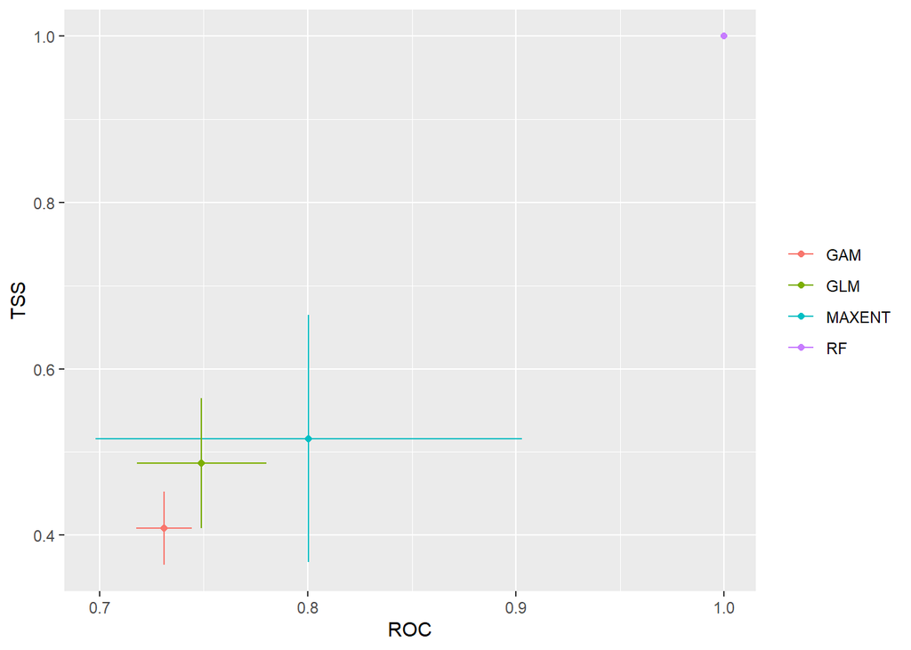

```r
# Set paths
table_path <- "Data/Processed_Data/Semi.bal/Individual-Visual/"
figure_path <- "Figures/Semi.bal/Individual-Visual/"

# Create folders if they don't exist
if (!dir.exists(table_path)) dir.create(table_path, recursive = TRUE)
if (!dir.exists(figure_path)) dir.create(figure_path, recursive = TRUE)

# Get evaluation scores & variable importance tables
eval_scores <- get_evaluations(myBiomodModelOut_semibalanus_visual)
var_imp <- get_variables_importance(myBiomodModelOut_semibalanus_visual)

write.csv(eval_scores, paste0(table_path, "Evaluations_All.csv"), row.names = TRUE)
write.csv(var_imp, paste0(table_path, "VariablesImportance_All.csv"), row.names = TRUE)

# calibration means
eval_calib <- bm_PlotEvalMean(bm.out = myBiomodModelOut_semibalanus_visual, dataset = "calibration")
```

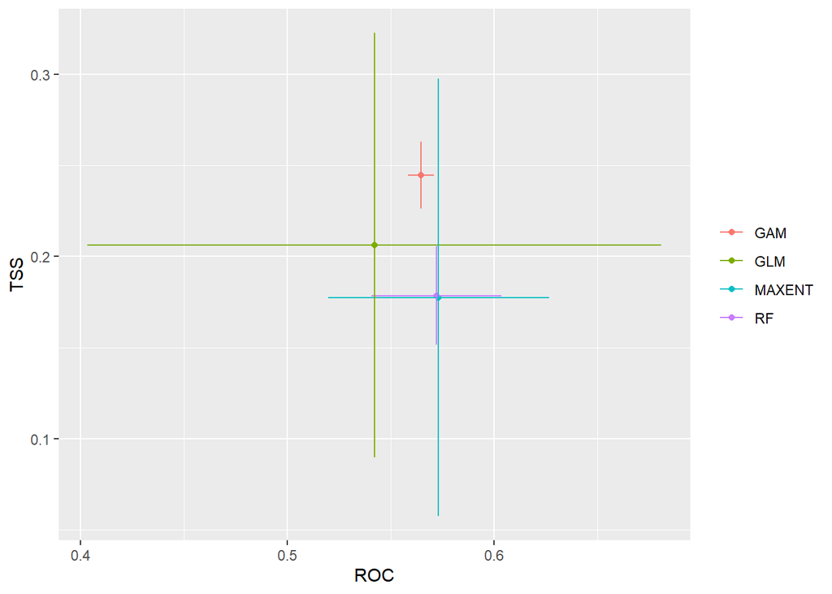

```r
algorithm_cal_plot_SB_CO <- eval_calib$plot + theme_classic() + labs(colour = "Algorithm")
tab <- eval_calib$tab

write.csv(tab, paste0(table_path, "EvalMean_Calibration.csv"), row.names = TRUE)
ggsave(algorithm_cal_plot_SB_CO, file = paste0(figure_path, "EvalMean_Calibration.png"), width = 7, height = 5)

# evaluation means
eval_eval <- bm_PlotEvalMean(bm.out = myBiomodModelOut_semibalanus_visual, dataset = "evaluation")
```

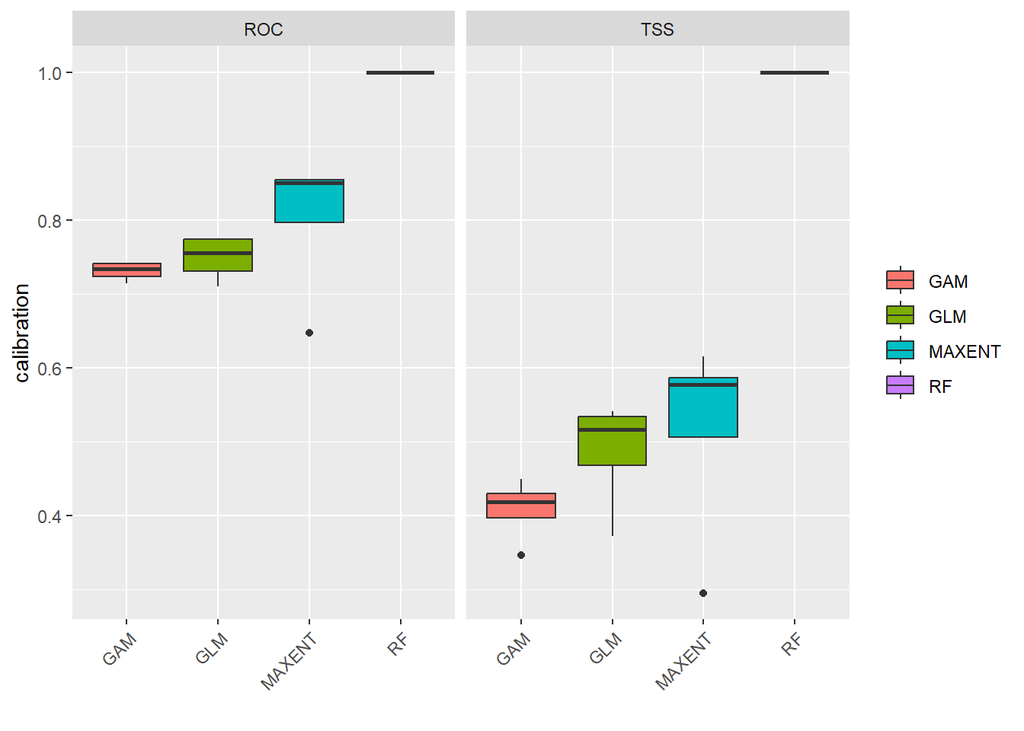

```r
algorithm_eval_plot_SB_CO <- eval_eval$plot + theme_classic() + labs(colour = "Algorithm")
tab <- eval_eval$tab
write.csv(tab, paste0(table_path, "EvalMean_Evaluation.csv"), row.names = TRUE)
ggsave(algorithm_eval_plot_SB_CO, file = paste0(figure_path, "EvalMean_Evaluation.png"), width = 7, height = 5)

# calibration boxplots - overall
# table produced here same as above, already saved
eval_boxplot_algo <- bm_PlotEvalBoxplot(bm.out = myBiomodModelOut_semibalanus_visual, group.by = c('algo', 'algo'))
```

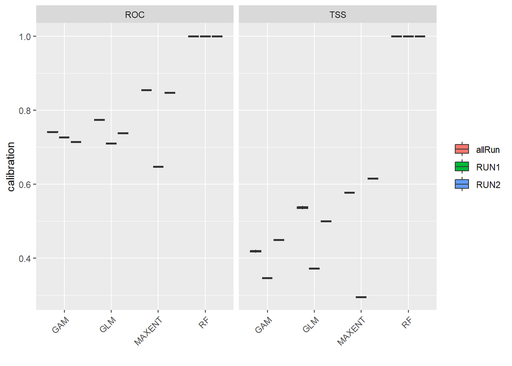

```r
plot <- eval_boxplot_algo$plot + theme_classic() + labs(fill = "Algorithm",
                                                y = "Calibration")
ggsave(plot, file = paste0(figure_path, "EvalMean_boxplot.png"), width = 7, height = 5)

# calibration boxplots - by run
eval_boxplot_algo_run <- bm_PlotEvalBoxplot(bm.out = myBiomodModelOut_semibalanus_visual, group.by = c('algo', 'run'))
```

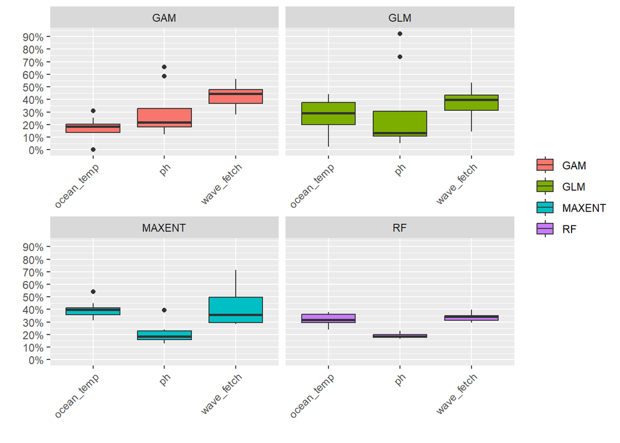

```r
plot <- eval_boxplot_algo_run$plot + theme_classic() + labs(fill = "Algorithm",
                                                y = "Calibration")
ggsave(plot, file = paste0(figure_path, "EvalMean_boxplot_run.png"), width = 8, height = 6)

# Variable importance boxplots - overall
# figures (table produced here same as above, already saved
val_importance_boxplot <- bm_PlotVarImpBoxplot(bm.out = myBiomodModelOut_semibalanus_visual, group.by = c('expl.var', 'algo', 'algo'))
```

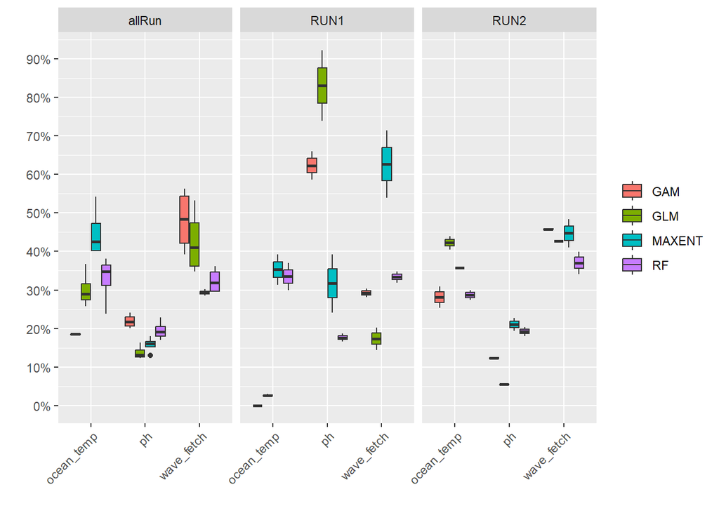

```r
plot <- val_importance_boxplot$plot + theme_classic() + labs(fill = "Algorithm")
ggsave(plot, file = paste0(figure_path, "VarImpBoxplot_ExplVar_Algo.png"), width = 8, height = 8)

# Variable importance boxplots - by run
val_importance_boxplot_run <- bm_PlotVarImpBoxplot(bm.out = myBiomodModelOut_semibalanus_visual, group.by = c('expl.var', 'algo', 'run'))
```

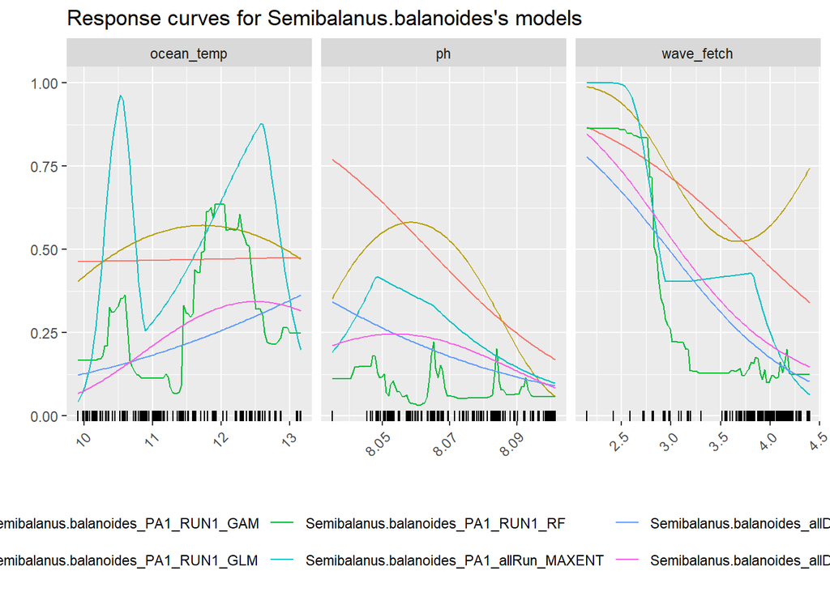

```r
plot <- val_importance_boxplot_run$plot + theme_classic() + labs(fill = "Algorithm")
ggsave(plot, file = paste0(figure_path, "VarImpBoxplot_ExplVar_Algo_Run.png"), width = 8, height = 6)

# Response curves
models_to_plot <- get_built_models(myBiomodModelOut_semibalanus_visual)[c(1:3, 12:14)]

# median
response_median <- bm_PlotResponseCurves(bm.out = myBiomodModelOut_semibalanus_visual,
                      models.chosen = models_to_plot,
                      fixed.var = 'median')
```

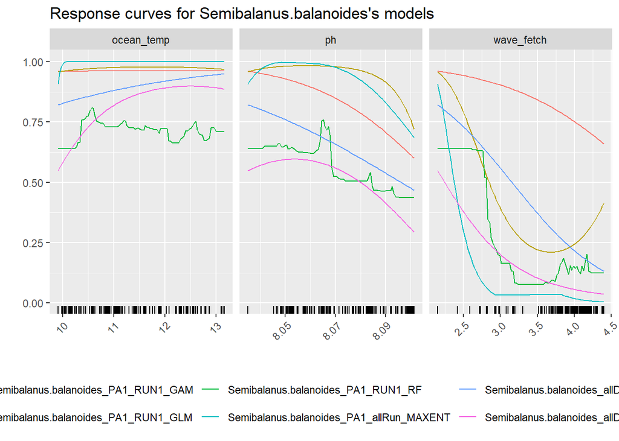

```r
tab <- response_median$tab
plot <- response_median$plot + theme_classic() + labs(colour = "Prediction Name")
write.csv(tab, paste0(table_path, "pred.vals.median.csv"), row.names = TRUE)
ggsave(plot, file = paste0(figure_path, "ResponseCurves_Median.png"), width = 13, height = 7)

# min
response_min<-bm_PlotResponseCurves(bm.out = myBiomodModelOut_semibalanus_visual,
                      models.chosen = models_to_plot,
                      fixed.var = 'min')
```